# BNLL Physiology - General Data Wrangling

Savannah Weaver

# Packages

```r
`%nin%` = Negate(`%in%`)
if (!require("tidyverse")) install.packages("tidyverse")
library("tidyverse") # workflow and plots
if (!require("rmdformats")) install.packages("rmdformats")
library("rmdformats") # clean html R markdown format
```

# Background and Goals

# Load Data

## CEWL

```r
CEWL <- read_rds("./data/CEWL_dat_all_clean.RDS") %>%
  # fix some upper/lowercase issues
  mutate(individual_ID = str_to_title(tolower(individual_ID)),
         # M-03a was originally W-029, so we need to reassign
         individual_ID = replace(individual_ID, individual_ID == "W-029", "M-03a"),
         individual_ID = factor(individual_ID))

summary(CEWL)
```

```
##       date            individual_ID   CEWL_g_m2h      msmt_temp_C
##  Min.   :2021-04-23   F-12   :  3   Min.   : 0.650   Min.   :19.00
##  1st Qu.:2021-04-24   M-11   :  3   1st Qu.: 8.486   1st Qu.:28.57
##  Median :2021-04-24   M-09   :  3   Median :10.381   Median :30.38
##  Mean   :2021-05-08   M-10   :  3   Mean   :10.272   Mean   :29.43
##  3rd Qu.:2021-05-08   M-19   :  3   3rd Qu.:12.881   3rd Qu.:31.52
##  Max.   :2021-07-14   M-20   :  3   Max.   :21.673   Max.   :33.55
##                       (Other):100
##  msmt_RH_percent    e_s_kPa       msmt_VPD_kPa
##  Min.   :11.84   Min.   :2.196   Min.   :1.371
##  1st Qu.:14.64   1st Qu.:3.906   1st Qu.:2.946
##  Median :16.12   Median :4.336   Median :3.635
##  Mean   :20.90   Mean   :4.160   Mean   :3.332
##  3rd Qu.:23.78   3rd Qu.:4.626   3rd Qu.:3.960
##  Max.   :40.22   Max.   :5.188   Max.   :4.319
##
```

```r
unique(CEWL$individual_ID)
```

```
##  [1] F-01  F-02  F-03  F-04  F-11  F-12  F-13  M-01  M-02  M-03  M-04  M-05
## [13] M-06  M-07  M-08  M-11  M-12  M-13  M-14  M-15  M-16  M-17  W-002 W-003
## [25] W-004 W-005 F-05  F-06  F-07  F-08  F-09  F-10  F-14  F-15  F-16  F-17
## [37] M-09  M-10  M-18  M-19  M-20  W-006 W-007 W-008 W-009 W-010 W-011 W-012
## [49] W-013 W-014 W-015 W-016 W-017 W-018 W-019 W-020 W-021 W-022 W-023 W-024
## [61] W-025 F-18  F-19  W-026 W-027 W-028 M-03a W-030 W-031 F-08a W-001 W-032
## [73] W-033 W-034 W-035 W-036 W-037 W-038 W-039
## 79 Levels: F-01 F-02 F-03 F-04 F-11 F-12 F-13 M-01 M-02 M-03 M-04 M-05 ... W-039
```

## Osmolality

```r
osmolality <- read_rds("./data/osml_means_clean.RDS")
summary(osmolality)
```

```
##  individual_ID blood_draw_date      osmolality_mmol_kg_mean
##  F-12   : 3    Min.   :2021-04-23   Min.   :309.3
##  M-09   : 3    1st Qu.:2021-04-24   1st Qu.:348.2
##  M-10   : 3    Median :2021-04-24   Median :366.5
##  M-11   : 3    Mean   :2021-05-08   Mean   :367.8
##  M-19   : 3    3rd Qu.:2021-05-08   3rd Qu.:379.9
##  M-20   : 3    Max.   :2021-07-14   Max.   :437.3
##  (Other):98
```

## Ultrasounding on Eggs

```r
eggs <- read.csv("./data/females_ultrasounding.csv") %>%
  mutate(ultrasound_date = as.Date(ultrasound_date, format = "%m/%d/%y"),
         individual_ID = factor(individual_ID),
         gravid_Y_N = factor(gravid_Y_N,
                             levels = c("Y", "N"),
                             labels = c("Gravid", "Not Gravid")),
         stage = str_trim(stage)) %>%
  left_join(read.csv("./data/female_egg_dvmt_key.csv"),
            by = c('stage' = 'name')) %>%
  mutate(stage = factor(stage,
                        levels = c("small round", "large round", "soft",
                                   "soft oblong", "firm oblong", "hard oblong")),
         dev_point = stage.y) %>%
  dplyr::select(-X, -stage.y) %>%
  mutate(month = factor(substr(as.character(ultrasound_date), 7, 7),
                          labels = c("April", "May")))

summary(eggs)
```

```
##  ultrasound_date      individual_ID      gravid_Y_N  number_eggs
##  Min.   :2021-04-24   F-01   : 2    Gravid    :16   Min.   :3.000
##  1st Qu.:2021-04-24   F-03   : 2    Not Gravid:12   1st Qu.:3.750
##  Median :2021-04-24   F-05   : 2                    Median :4.000
##  Mean   :2021-04-29   F-06   : 2                    Mean   :3.812
##  3rd Qu.:2021-05-08   F-11   : 2                    3rd Qu.:4.000
##  Max.   :2021-05-08   F-12   : 2                    Max.   :5.000
##                       (Other):16                    NA's   :12
##  largest_egg_diameter_cm largest_egg_circumference_cm         stage
##  Min.   :0.5700          Min.   :1.710                small round: 1
##  1st Qu.:0.8425          1st Qu.:2.385                large round: 9
##  Median :0.9950          Median :2.885                soft       : 2
##  Mean   :1.1131          Mean   :3.148                soft oblong: 1
##  3rd Qu.:1.4200          3rd Qu.:3.985                firm oblong: 2
##  Max.   :1.8000          Max.   :4.740                hard oblong: 1
##  NA's   :12              NA's   :12                   NA's       :12
##    dev_point      month
##  Min.   :1.00   April:17
##  1st Qu.:2.00   May  :11
##  Median :2.00
##  Mean   :2.75
##  3rd Qu.:3.25
##  Max.   :5.00
##  NA's   :12
```

## Radio-Collared Lizards

```r
lizards_collared <- read.csv("./data/collared_measurements.csv") %>%
  mutate(capture_process_date_time = as.POSIXct(paste(capture_process_date,
                                                      capture_time,
                                                      sep = " "),
                                                format = "%m/%d/%y %H:%M"),
                capture_process_date = as.Date(capture_process_date,
                                                  format = "%m/%d/%y"),
                SVL_mm = as.numeric(SVL_mm),
                pre_tmt_mass_g = as.numeric(pre_tmt_mass_g),
                pre_mass_w_collar_Y_N = as.factor(pre_mass_w_collar_Y_N),
                post_tmt_mass_g = as.numeric(post_tmt_mass_g),
                post_mass_w_collar_Y_N = as.factor(post_mass_w_collar_Y_N),
                treatment_date_time = as.POSIXct(paste(treatment_date,
                                                       processing_time,
                                                       sep = " "),
                                                 format = "%m/%d/%y %H:%M"),
                tmt_start_time = as.POSIXct(tmt_start_time, format = "%H:%M"),
                tmt_end_time = as.POSIXct(tmt_end_time, format = "%H:%M"),
                hematocrit_percent = as.numeric(hematocrit_percent),
                cloacal_temp_C = as.numeric(cloacal_temp_C)
                ) %>%
  # add tmt group info
  left_join(read.csv("./data/collared_identification.csv"),
            by = 'individual_ID') %>%
                # format data classes
  dplyr::mutate(individual_ID = as.factor(individual_ID),
                sex_M_F = as.factor(sex),
                tmt = as.factor(tmt),
                radio_collar_mass_g = as.numeric(radio_collar_mass_g),
                #statistics
                capture_to_msmt = as.numeric(treatment_date_time - capture_process_date_time),
                tmt_time_elapsed = as.numeric(tmt_end_time - tmt_start_time),
                actual_pre_tmt_mass_g = pre_tmt_mass_g - radio_collar_mass_g*(pre_mass_w_collar_Y_N == "Y"),
                actual_post_tmt_mass_g = post_tmt_mass_g - radio_collar_mass_g*(post_mass_w_collar_Y_N == "Y"),
                tmt_mass_change_g = actual_post_tmt_mass_g - actual_pre_tmt_mass_g,
                radio_collar_percent_mass_g = radio_collar_mass_g/actual_pre_tmt_mass_g
                ) %>%
  dplyr::select(capture_date_time = capture_process_date_time,
                capture_date = capture_process_date,
                treatment_date_time,
                radio_collar_serial,
                PIT_tag_ID,
                individual_ID,
                sex_M_F,
                mass_g = actual_pre_tmt_mass_g,
                SVL_mm,
                tmt,
                tmt_time_elapsed,
                tmt_mass_change_g,
                radio_collar_mass_g,
                radio_collar_percent_mass_g,
                capture_to_msmt,
                hematocrit_percent,
                cloacal_temp_C
                )

summary(lizards_collared)
```

```
##  capture_date_time                 capture_date
##  Min.   :2021-04-23 10:39:00.00   Min.   :2021-04-23
##  1st Qu.:2021-04-23 14:54:30.00   1st Qu.:2021-04-23
##  Median :2021-04-24 10:50:30.00   Median :2021-04-25
##  Mean   :2021-04-28 14:03:08.27   Mean   :2021-05-12
##  3rd Qu.:2021-05-07 11:41:30.00   3rd Qu.:2021-05-08
##  Max.   :2021-05-08 14:19:00.00   Max.   :2021-07-14
##  NA's   :18
##  treatment_date_time              radio_collar_serial  PIT_tag_ID
##  Min.   :2021-04-23 12:05:00.00   Length:76           Length:76
##  1st Qu.:2021-04-24 11:49:30.00   Class :character    Class :character
##  Median :2021-04-26 13:30:00.00   Mode  :character    Mode  :character
##  Mean   :2021-05-13 12:15:23.68
##  3rd Qu.:2021-05-08 13:49:00.00
##  Max.   :2021-07-14 16:48:00.00
##
##  individual_ID sex_M_F     mass_g          SVL_mm             tmt
##  F-12   : 3    F:32    Min.   :25.00   Min.   : 85.0   control  :38
##  M-09   : 3    M:44    1st Qu.:33.70   1st Qu.: 96.0   hydration:38
##  M-10   : 3            Median :38.00   Median :100.0
##  M-11   : 3            Mean   :39.20   Mean   :101.7
##  M-19   : 3            3rd Qu.:43.45   3rd Qu.:108.0
##  M-20   : 3            Max.   :58.80   Max.   :122.0
##  (Other):58
##  tmt_time_elapsed tmt_mass_change_g radio_collar_mass_g
##  Min.   :  6.00   Min.   :-3.0000   Min.   :1.900
##  1st Qu.: 23.00   1st Qu.:-1.0000   1st Qu.:2.000
##  Median : 27.00   Median : 0.0000   Median :2.100
##  Mean   : 54.47   Mean   :-0.2262   Mean   :2.172
##  3rd Qu.: 47.00   3rd Qu.: 0.0000   3rd Qu.:2.300
##  Max.   :205.00   Max.   : 3.0000   Max.   :2.700
##  NA's   :19       NA's   :15
##  radio_collar_percent_mass_g capture_to_msmt  hematocrit_percent
##  Min.   :0.03393             Min.   :  11.0   Min.   :17.00
##  1st Qu.:0.04783             1st Qu.:  62.5   1st Qu.:30.00
##  Median :0.05664             Median : 152.0   Median :34.00
##  Mean   :0.05752             Mean   : 401.1   Mean   :34.35
##  3rd Qu.:0.06685             3rd Qu.: 265.2   3rd Qu.:38.50
##  Max.   :0.08621             Max.   :1665.0   Max.   :58.00
##                              NA's   :18       NA's   :1
##  cloacal_temp_C
##  Min.   :24.00
##  1st Qu.:30.00
##  Median :32.00
##  Mean   :31.92
##  3rd Qu.:34.00
##  Max.   :36.00
##
```

```r
unique(lizards_collared$radio_collar_serial)
```

```
##  [1] "245-761"  "252-886"  "245-762"  "252-887"  "245-753"  "245-752"
##  [7] "245-754"  "229-079"  "245-744"  "229-069"  "252-885"  "245-759"
## [13] "245-751"  "245-757"  "229-059"  "229-063"  "245-747"  "229-070"
## [19] "229-065"  "245-741"  "245-748"  "252-882"  "252-881"  "229-078"
## [25] "245-750"  "229-080"  "245-760"  "245-746"  "245-745"  "245-742"
## [31] "252-884"  "252-883"  "245-756"  "229-073"  "229-066"  "229-072"
## [37] "229-060"  "229-074"  "229-077"  "245-762a" "229-070a"
```

## Widespread Lizards

```r
lizards_widespread <- read.csv("./data/widespread_measurements.csv") %>%
                # format data classes
  dplyr::mutate(capture_date_time = as.POSIXct(paste(date,
                                                      capture_time,
                                                      sep = " "),
                                                format = "%m/%d/%y %H:%M"),
                capture_date = as.Date(date, format = "%m/%d/%y"),
                capture_time = as.POSIXct(capture_time, format = "%H:%M"),
                processing_time = as.POSIXct(processing_time, format = "%H:%M"),
                individual_ID = as.factor(individual_ID),
                SVL_mm = as.numeric(SVL_mm),
                mass_g = as.numeric(mass_g),
                sex_M_F = as.factor(sex_M_F),
                hematocrit_percent = as.numeric(hematocrit_percent),
                cloacal_temp_C = as.numeric(cloacal_temp_C),
                # statistics
                capture_to_msmt = as.numeric(processing_time - capture_time),
                # add things to match with treatment lizards
                tmt = as.factor("No Tmt"),
                radio_collar_serial = NA,
                tmt_mass_change_g = 0
                ) %>%
  dplyr::select(capture_date_time,
                capture_date,
                PIT_tag_ID,
                individual_ID,
                sex_M_F,
                mass_g,
                SVL_mm,
                capture_to_msmt,
                hematocrit_percent,
                cloacal_temp_C,
                radio_collar_serial,
                tmt, tmt_mass_change_g
                )

summary(lizards_widespread)
```

```
##  capture_date_time                capture_date         PIT_tag_ID
##  Min.   :2021-04-23 11:05:00.0   Min.   :2021-04-23   Length:43
##  1st Qu.:2021-04-24 11:33:00.0   1st Qu.:2021-04-24   Class :character
##  Median :2021-04-24 13:36:00.0   Median :2021-04-24   Mode  :character
##  Mean   :2021-04-28 14:15:49.5   Mean   :2021-04-30
##  3rd Qu.:2021-05-07 16:00:00.0   3rd Qu.:2021-05-08
##  Max.   :2021-05-08 12:58:00.0   Max.   :2021-07-14
##  NA's   :3
##  individual_ID sex_M_F     mass_g          SVL_mm       capture_to_msmt
##  W-001  : 2    F:12    Min.   :20.00   Min.   : 77.00   Min.   : 10.00
##  W-002  : 2    M:31    1st Qu.:24.50   1st Qu.: 85.50   1st Qu.: 26.75
##  W-016  : 2            Median :31.00   Median : 95.00   Median : 70.00
##  W-017  : 2            Mean   :32.95   Mean   : 94.26   Mean   : 95.03
##  W-025  : 2            3rd Qu.:41.50   3rd Qu.:101.00   3rd Qu.:126.50
##  W-003  : 1            Max.   :53.00   Max.   :114.00   Max.   :307.00
##  (Other):32                                             NA's   :3
##  hematocrit_percent cloacal_temp_C  radio_collar_serial     tmt
##  Min.   :10.00      Min.   :22.00   Mode:logical        No Tmt:43
##  1st Qu.:30.00      1st Qu.:32.00   NA's:43
##  Median :33.00      Median :34.00
##  Mean   :32.73      Mean   :32.74
##  3rd Qu.:37.00      3rd Qu.:34.00
##  Max.   :49.00      Max.   :36.00
##  NA's   :2
##  tmt_mass_change_g
##  Min.   :0
##  1st Qu.:0
##  Median :0
##  Mean   :0
##  3rd Qu.:0
##  Max.   :0
##
```

# Methods Stats

How many lizards were captured/measured when?

```r
# lizards that were radio-collared
length(unique(lizards_collared$individual_ID))
```

```
## [1] 41
```

```r
# other lizards
length(unique(lizards_widespread$individual_ID))
```

```
## [1] 38
```

```r
# total lizards
length(unique(lizards_collared$individual_ID)) + length(unique(lizards_widespread$individual_ID))
```

```
## [1] 79
```

```r
# by date
lizards_widespread %>%
  group_by(capture_date) %>%
  summarise(n = n())
```

```
## # A tibble: 6 × 2
##   capture_date     n
##   <date>       <int>
## 1 2021-04-23       5
## 2 2021-04-24      20
## 3 2021-04-25       3
## 4 2021-05-07       3
## 5 2021-05-08      11
## 6 2021-07-14       1
```

```r
# by date
lizards_collared %>%
  group_by(capture_date) %>%
  summarise(n = n())
```

```
## # A tibble: 6 × 2
##   capture_date     n
##   <date>       <int>
## 1 2021-04-23      22
## 2 2021-04-24      15
## 3 2021-04-25       2
## 4 2021-05-07      10
## 5 2021-05-08      13
## 6 2021-07-14      14
```

```r
# which widespread were recaptured and when
lizards_widespread %>%
  group_by(individual_ID) %>%
  summarise(n = n()) %>%
  dplyr::filter(n > 1) -> recap_W
lizards_widespread %>%
  dplyr::filter(individual_ID %in% recap_W$individual_ID) %>%
  arrange(individual_ID)
```

```
##      capture_date_time capture_date  PIT_tag_ID individual_ID sex_M_F mass_g
## 1  2021-04-23 11:38:00   2021-04-23 844-852-127         W-001       M     22
## 2                 <NA>   2021-05-08 844-852-127         W-001       M     25
## 3  2021-04-23 12:17:00   2021-04-23 844-848-311         W-002       M     25
## 4  2021-05-07 13:23:00   2021-05-07 844-848-311         W-002       M     27
## 5  2021-04-24 11:35:00   2021-04-24 835-838-892         W-016       M     42
## 6  2021-05-08 12:35:00   2021-05-08 835-838-892         W-016       M     46
## 7  2021-04-24 11:59:00   2021-04-24 835-834-109         W-017       M     26
## 8  2021-05-08 12:48:00   2021-05-08 835-834-109         W-017       M     30
## 9  2021-04-24 14:22:00   2021-04-24 835-852-372         W-025       M     34
## 10 2021-05-08 12:41:00   2021-05-08 835-852-372         W-025       M     31
##    SVL_mm capture_to_msmt hematocrit_percent cloacal_temp_C radio_collar_serial
## 1      84              15                 NA             34                  NA
## 2      86              NA                 41             35                  NA
## 3      77              61                 29             34                  NA
```

[output cut: 18 more lines]

```r
# which collared were recaptured and when
lizards_collared %>%
  group_by(individual_ID) %>%
  summarise(n = n()) %>%
  dplyr::filter(n > 1) -> recap_C
lizards_collared %>%
  dplyr::filter(individual_ID %in% recap_C$individual_ID) %>%
  arrange(individual_ID)
```

```
##      capture_date_time capture_date treatment_date_time radio_collar_serial
## 1  2021-04-23 12:50:00   2021-04-23 2021-04-23 13:29:00             252-885
## 2                 <NA>   2021-05-08 2021-05-08 13:16:00             252-885
## 3  2021-04-23 11:39:00   2021-04-23 2021-04-23 14:13:00             245-751
## 4  2021-05-08 09:24:00   2021-05-08 2021-05-08 13:47:00             245-751
## 5  2021-04-24 10:49:00   2021-04-24 2021-04-24 11:51:00             229-059
## 6  2021-05-08 08:40:00   2021-05-08 2021-05-08 12:56:00             229-059
## 7  2021-04-24 11:48:00   2021-04-24 2021-04-24 12:32:00             229-063
## 8  2021-05-08 08:54:00   2021-05-08 2021-05-08 12:58:00             229-063
## 9  2021-04-24 13:50:00   2021-04-24 2021-04-24 14:25:00             245-741
## 10                <NA>   2021-07-14 2021-07-14 12:29:00             245-741
## 11 2021-04-23 12:00:00   2021-04-23 2021-04-23 14:20:00             252-884
## 12 2021-05-08 11:00:00   2021-05-08 2021-05-08 13:34:00             252-884
## 13 2021-04-23 14:00:00   2021-04-23 2021-04-23 14:36:00             252-883
## 14                <NA>   2021-05-08 2021-05-08 13:13:00             252-883
```

[output cut: 245 more lines]

```r
# check things
lizards_collared %>%
  dplyr::filter(individual_ID %nin% recap_C$individual_ID)
```

```
##      capture_date_time capture_date treatment_date_time radio_collar_serial
## 1  2021-04-23 10:43:00   2021-04-23 2021-04-23 13:23:00             252-886
## 2  2021-04-23 12:34:00   2021-04-23 2021-04-23 13:47:00             245-762
## 3  2021-04-23 11:19:00   2021-04-23 2021-04-23 13:49:00             245-759
## 4  2021-04-23 14:56:00   2021-04-23 2021-04-24 18:41:00             245-757
## 5  2021-04-24 11:10:00   2021-04-24 2021-04-24 13:08:00             245-747
## 6  2021-04-24 11:11:00   2021-04-24 2021-04-24 13:23:00             229-070
## 7  2021-04-24 12:56:00   2021-04-24 2021-04-24 14:03:00             229-065
## 8  2021-04-23 15:27:00   2021-04-23 2021-04-24 18:17:00             245-750
## 9  2021-04-24 09:57:00   2021-04-24 2021-04-24 11:28:00             229-073
## 10 2021-04-24 10:49:00   2021-04-24 2021-04-24 11:37:00             229-066
## 11 2021-04-25 11:17:00   2021-04-25 2021-04-26 13:30:00             229-074
## 12 2021-05-08 14:19:00   2021-05-08 2021-05-08 15:08:00            229-070a
##     PIT_tag_ID individual_ID sex_M_F mass_g SVL_mm       tmt tmt_time_elapsed
## 1  844-858-121          M-02       M     32     96 hydration              113
```

[output cut: 37 more lines]

```r
lizards_widespread %>% dplyr::filter(individual_ID == "W-029")
```

```
##  [1] capture_date_time   capture_date        PIT_tag_ID
##  [4] individual_ID       sex_M_F             mass_g
##  [7] SVL_mm              capture_to_msmt     hematocrit_percent
## [10] cloacal_temp_C      radio_collar_serial tmt
## [13] tmt_mass_change_g
## <0 rows> (or 0-length row.names)
```

```r
lizards_collared %>% dplyr::filter(individual_ID == "M-03a") # but does he have April?? if not, add as a new capture for May (not added rn)
```

```
##     capture_date_time capture_date treatment_date_time radio_collar_serial
## 1 2021-05-07 13:34:00   2021-05-07 2021-05-08 11:47:00            245-762a
## 2                <NA>   2021-07-14 2021-07-14 12:51:00            245-762a
##    PIT_tag_ID individual_ID sex_M_F mass_g SVL_mm       tmt tmt_time_elapsed
## 1 845-578-768         M-03a       M   50.8    113 hydration               35
## 2 845-578-768         M-03a       M   42.0    113 hydration               NA
##   tmt_mass_change_g radio_collar_mass_g radio_collar_percent_mass_g
## 1                 1                 2.2                  0.04330709
## 2                NA                 2.2                  0.05238095
##   capture_to_msmt hematocrit_percent cloacal_temp_C
## 1            1333                 44             33
## 2              NA                 30             29
```

```r
# if he has an Apri msmt, then add 1 recap to May, if not, leve as-is
```

Throughout the summer, we measured 41 collared lizards, & 38 widespread lizards.

Of the 38 widespread lizards, 28 were captured in April, 9 in May, and 1 in July. 5 of the widespread lizards captured in April were recaptured in May.

How long were lizards held between capture and measurement?

```r
# collared
mean(lizards_collared$capture_to_msmt, na.rm = TRUE)/60 # hours
```

```
## [1] 6.685345
```

```r
median(lizards_collared$capture_to_msmt, na.rm = TRUE)/60
```

```
## [1] 2.533333
```

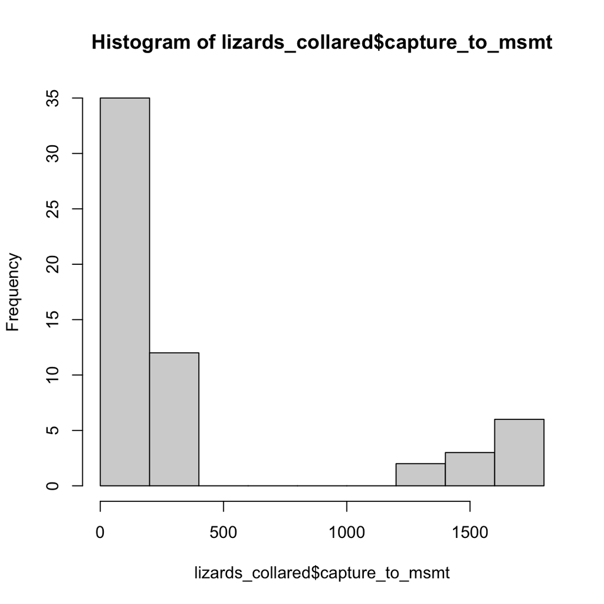

```r
hist(lizards_collared$capture_to_msmt)
```

```r
300/60
```

```
## [1] 5
```

```r
# widespread
mean(lizards_widespread$capture_to_msmt, na.rm = TRUE) # minutes
```

```
## [1] 95.025
```

```r
max(lizards_widespread$capture_to_msmt, na.rm = TRUE)
```

```
## [1] 307
```

How long were treatment lizards in treatment?

```r
mean(lizards_collared$tmt_time_elapsed, na.rm = T)
```

```
## [1] 54.47368
```

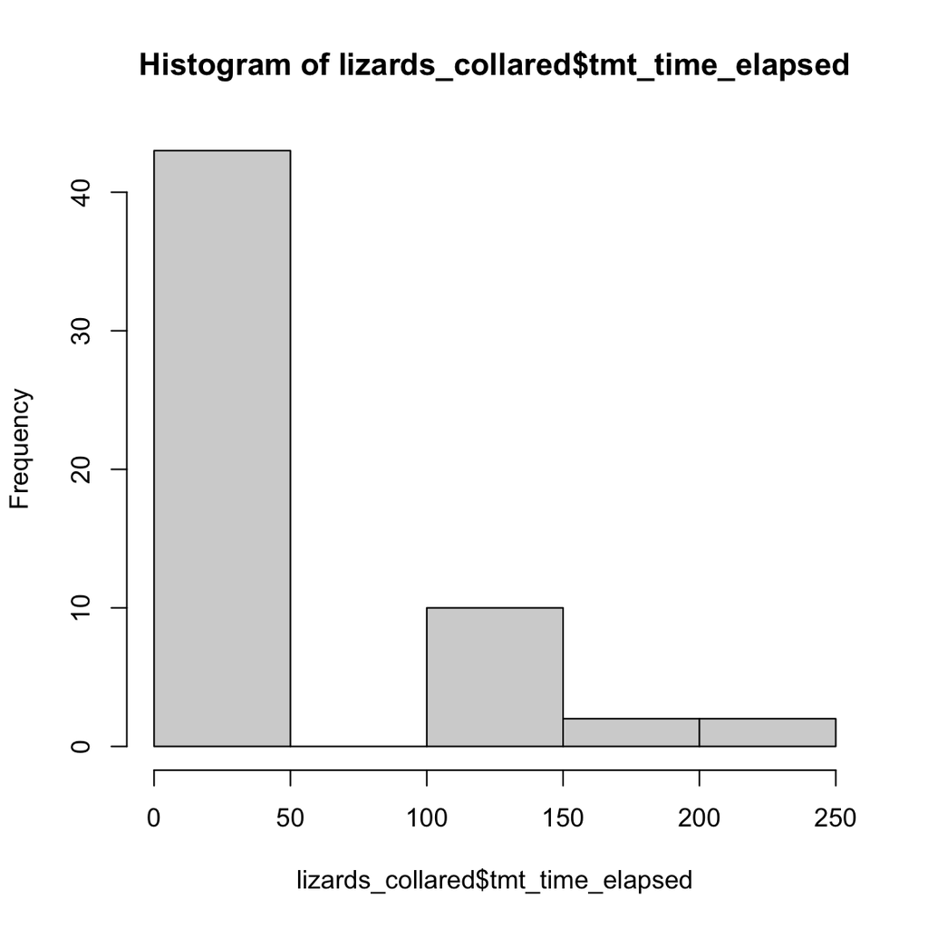

```r
hist(lizards_collared$tmt_time_elapsed, na.rm = T)
```

Lizards were put in bins with shallow water for 1 hour, on average, to promote drinking behavior.

# Merge dfs

```r
merged_data <- lizards_collared %>%
  # remove collared info we only needed for methods summary
  dplyr::select(-treatment_date_time, -tmt_time_elapsed,
                -radio_collar_mass_g, -radio_collar_percent_mass_g
                ) %>%
  # add widespread lizards
  rbind(lizards_widespread) %>%
  # join CEWL data
  left_join(CEWL, by = c('individual_ID',
                         'capture_date' = 'date')) %>%
  # join osmolality data
  left_join(osmolality, by = c('individual_ID',
                               'capture_date' = 'blood_draw_date')) %>%
  # relabel and add factors for informative grouping
  mutate(sex_M_F = factor(sex_M_F, labels = c("Female", "Male")),
         tmt = factor(tmt, levels = c("hydration", "control", "No Tmt"),
                           labels = c("Water Tmt", "Sham Tmt", "No Tmt")),
         month = factor(substr(as.character(capture_date), 7, 7),
                          labels = c("April", "May", "July")),
         week = factor(month,
                       labels = c("1", "3", "12")),
         week_num = as.numeric(as.character(week))) %>%
  # join female gravidity notes
  left_join(eggs, by = c('individual_ID', 'month'))

summary(merged_data)
```

```
##  capture_date_time                 capture_date        radio_collar_serial
##  Min.   :2021-04-23 10:39:00.00   Min.   :2021-04-23   Length:119
##  1st Qu.:2021-04-23 15:39:15.00   1st Qu.:2021-04-24   Class :character
##  Median :2021-04-24 12:22:00.00   Median :2021-04-24   Mode  :character
##  Mean   :2021-04-28 14:08:18.98   Mean   :2021-05-08
##  3rd Qu.:2021-05-07 13:16:45.00   3rd Qu.:2021-05-08
##  Max.   :2021-05-08 14:19:00.00   Max.   :2021-07-14
##  NA's   :21
##   PIT_tag_ID        individual_ID   sex_M_F       mass_g          SVL_mm
##  Length:119         F-12   :  3   Female:44   Min.   :20.00   Min.   : 77.0
##  Class :character   M-09   :  3   Male  :75   1st Qu.:31.00   1st Qu.: 93.5
##  Mode  :character   M-10   :  3               Median :37.00   Median : 99.0
##                     M-11   :  3               Mean   :36.94   Mean   : 99.0
##                     M-19   :  3               3rd Qu.:43.00   3rd Qu.:106.5
##                     M-20   :  3               Max.   :58.80   Max.   :122.0
##                     (Other):101
##         tmt     tmt_mass_change_g capture_to_msmt   hematocrit_percent
##  Water Tmt:38   Min.   :-3.0000   Min.   :  10.00   Min.   :10.00
##  Sham Tmt :38   1st Qu.:-0.1500   1st Qu.:  49.25   1st Qu.:30.00
##  No Tmt   :43   Median : 0.0000   Median : 117.50   Median :34.00
##                 Mean   :-0.1327   Mean   : 276.18   Mean   :33.78
##                 3rd Qu.: 0.0000   3rd Qu.: 228.75   3rd Qu.:38.00
##                 Max.   : 3.0000   Max.   :1665.00   Max.   :58.00
##                 NA's   :15        NA's   :21        NA's   :3
##  cloacal_temp_C    CEWL_g_m2h      msmt_temp_C    msmt_RH_percent
##  Min.   :22.00   Min.   : 0.650   Min.   :19.00   Min.   :11.84
##  1st Qu.:31.00   1st Qu.: 8.486   1st Qu.:28.57   1st Qu.:14.64
##  Median :33.00   Median :10.381   Median :30.38   Median :16.12
##  Mean   :32.22   Mean   :10.272   Mean   :29.43   Mean   :20.90
##  3rd Qu.:34.00   3rd Qu.:12.881   3rd Qu.:31.52   3rd Qu.:23.78
##  Max.   :36.00   Max.   :21.673   Max.   :33.55   Max.   :40.22
##                  NA's   :1        NA's   :1       NA's   :1
##     e_s_kPa       msmt_VPD_kPa   osmolality_mmol_kg_mean   month    week
##  Min.   :2.196   Min.   :1.371   Min.   :309.3           April:67   1 :67
##  1st Qu.:3.906   1st Qu.:2.946   1st Qu.:348.2           May  :37   3 :37
##  Median :4.336   Median :3.635   Median :366.5           July :15   12:15
##  Mean   :4.160   Mean   :3.332   Mean   :367.8
##  3rd Qu.:4.626   3rd Qu.:3.960   3rd Qu.:379.9
##  Max.   :5.188   Max.   :4.319   Max.   :437.3
##  NA's   :1       NA's   :1       NA's   :3
```

[output cut: 9 more lines]

```
##  Min.   :0.5700          Min.   :1.710                small round:  1
##  1st Qu.:0.8425          1st Qu.:2.385                large round:  9
##  Median :0.9950          Median :2.885                soft       :  2
##  Mean   :1.1131          Mean   :3.148                soft oblong:  1
##  3rd Qu.:1.4200          3rd Qu.:3.985                firm oblong:  2
##  Max.   :1.8000          Max.   :4.740                hard oblong:  1
##  NA's   :103             NA's   :103                  NA's       :103
##    dev_point
##  Min.   :1.00
##  1st Qu.:2.00
##  Median :2.00
##  Mean   :2.75
##  3rd Qu.:3.25
##  Max.   :5.00
##  NA's   :103
```

# Calculate Body Condition

This is also known as scaled mass index, or log-log residuals.

I calculate as described by: Peig, J., & Green, A. J. (2009). New perspectives for estimating body condition from mass/length data: The scaled mass index as an alternative method. Oikos, 118(12), 1883–1891. https://doi.org/10.1111/j.1600-0706.2009.17643.x

Step 0:

get subset of data with only April data:

```r
April_lizard_dat <- merged_data %>%
  dplyr::filter(month == "April")
```

Step 1: Simple Linear Regression

```r
mass_SVL_SLR <- lm(data = April_lizard_dat, mass_g ~ SVL_mm)
summary(mass_SVL_SLR)
```

```
##
## Call:
## lm(formula = mass_g ~ SVL_mm, data = April_lizard_dat)
##
## Residuals:
##      Min       1Q   Median       3Q      Max
## -10.9407  -2.3792  -0.3926   2.0113  11.2922
##
## Coefficients:
##              Estimate Std. Error t value Pr(>|t|)
## (Intercept) -38.37511    4.95184   -7.75 8.13e-11 ***
## SVL_mm        0.75343    0.05058   14.90  < 2e-16 ***
## ---
## Signif. codes:  0 '***' 0.001 '**' 0.01 '*' 0.05 '.' 0.1 ' ' 1
##
## Residual standard error: 4.394 on 65 degrees of freedom
## Multiple R-squared:  0.7734, Adjusted R-squared:   0.77
## F-statistic: 221.9 on 1 and 65 DF,  p-value: < 2.2e-16
```

Step 2: Identify Outliers

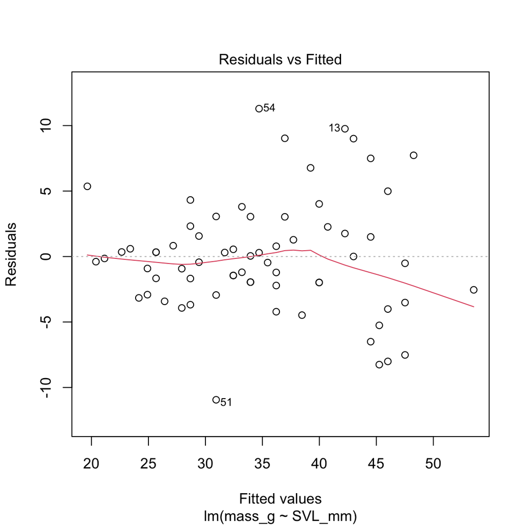

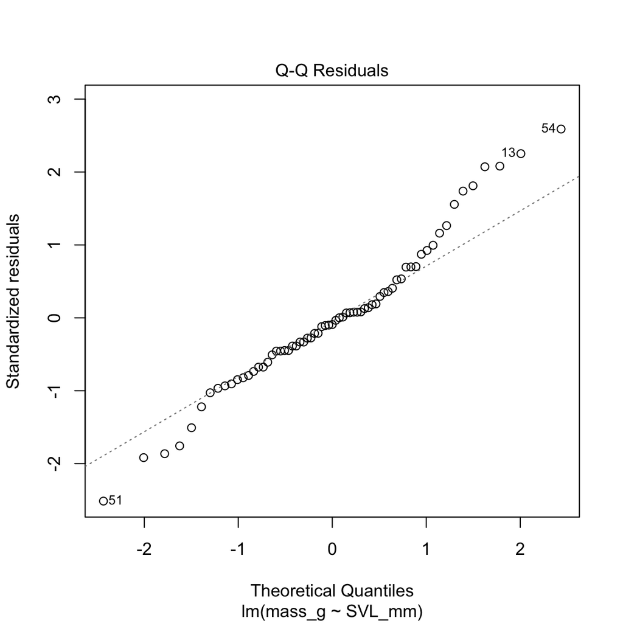

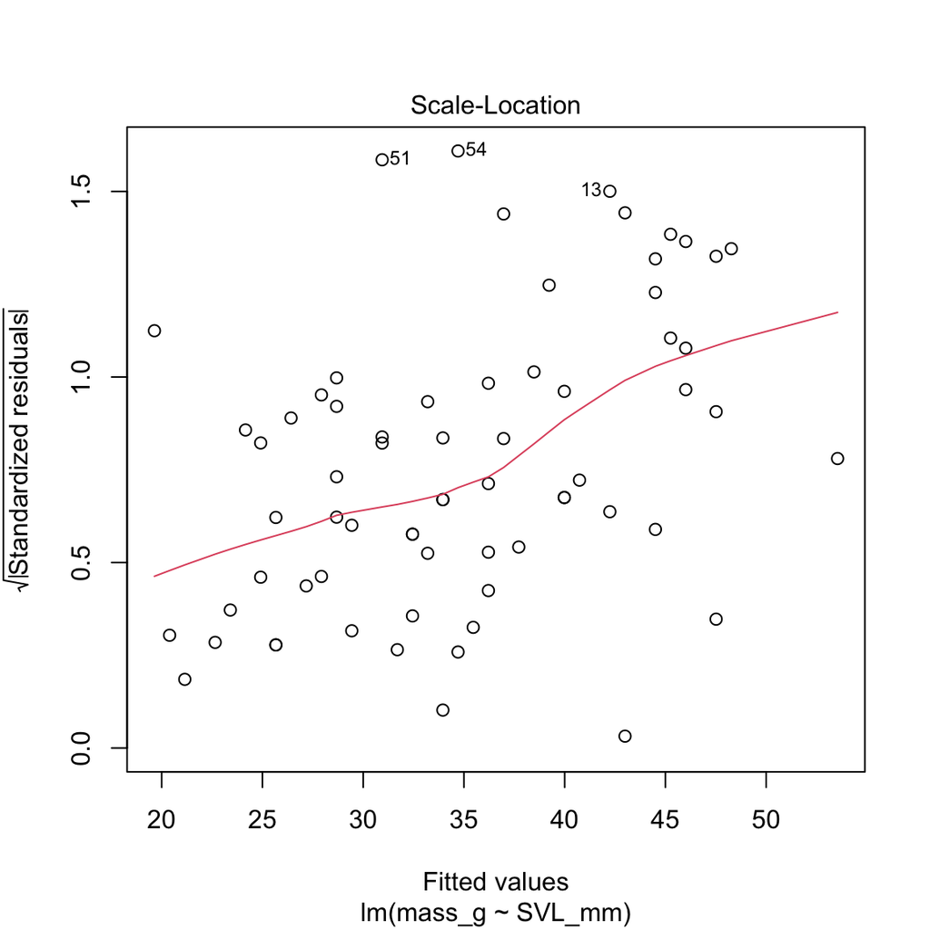

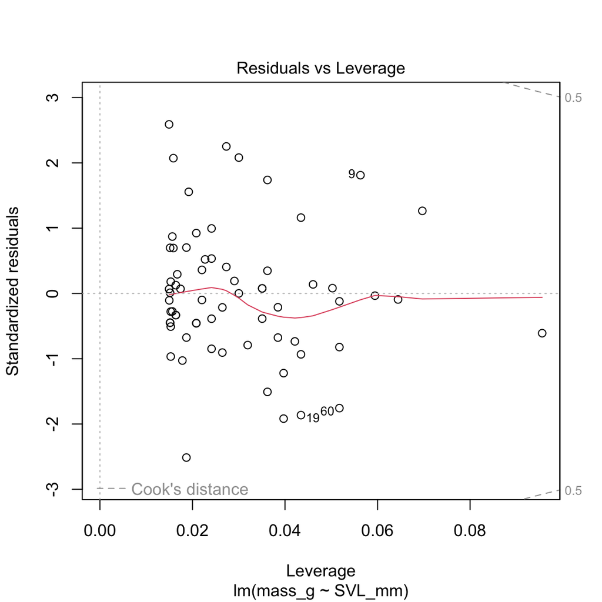

```r
plot(mass_SVL_SLR)
```

Hm, residuals are fanned-out, and many have high values, but they are pretty evenly distributed on either side of zero.

So, check for high leverage points:

```r
# compute values for observations
high_leverage <- data.frame(H = hatvalues(mass_SVL_SLR)) %>%
  mutate(row = rownames(.))

# compute cutoff value
h_bar <- (3*sum(high_leverage$H))/nrow(high_leverage)

# add to original dataframe
# see which observations have extremely high leverage (if any)
high_leverage_dat <- April_lizard_dat %>%
  dplyr::mutate(residuals = residuals(mass_SVL_SLR)) %>%
  dplyr::mutate(row = rownames(.)) %>%
  left_join(., high_leverage, by = "row") %>%
  dplyr::filter(H > h_bar)
high_leverage_dat
```

```
##     capture_date_time capture_date radio_collar_serial  PIT_tag_ID
## 1 2021-04-24 10:52:00   2021-04-24             245-742 844-869-264
##   individual_ID sex_M_F mass_g SVL_mm      tmt tmt_mass_change_g
## 1          M-20    Male     51    122 Sham Tmt                -1
##   capture_to_msmt hematocrit_percent cloacal_temp_C CEWL_g_m2h msmt_temp_C
## 1             130                 30             32   7.993333    29.36667
##   msmt_RH_percent  e_s_kPa msmt_VPD_kPa osmolality_mmol_kg_mean month week
## 1        18.73333 4.090158     3.323935                   373.5 April    1
##   week_num ultrasound_date gravid_Y_N number_eggs largest_egg_diameter_cm
## 1        1            <NA>       <NA>          NA                      NA
##   largest_egg_circumference_cm stage dev_point residuals row          H
## 1                           NA  <NA>        NA -2.543636  30 0.09558099
```

The point for individual M-20 seems to be high-leverage, so we will try removing

Check for influential points based on Cook’s distance:

```r
# get Cook's distance
cooks <- data.frame(c = cooks.distance(mass_SVL_SLR) # specify model name
                    ) %>% mutate(row = rownames(.))

# add to original dataframe
influential <- April_lizard_dat %>%
  dplyr::mutate(residuals = residuals(mass_SVL_SLR)) %>%
  dplyr::mutate(row = rownames(.)) %>%
  left_join(., cooks, by = "row")

# see moderately influential points
cook_mod_inf <- influential %>%
  dplyr::filter(c>0.5)
cook_mod_inf
```

```
##  [1] capture_date_time            capture_date
##  [3] radio_collar_serial          PIT_tag_ID
##  [5] individual_ID                sex_M_F
##  [7] mass_g                       SVL_mm
##  [9] tmt                          tmt_mass_change_g
## [11] capture_to_msmt              hematocrit_percent
## [13] cloacal_temp_C               CEWL_g_m2h
## [15] msmt_temp_C                  msmt_RH_percent
## [17] e_s_kPa                      msmt_VPD_kPa
## [19] osmolality_mmol_kg_mean      month
## [21] week                         week_num
## [23] ultrasound_date              gravid_Y_N
## [25] number_eggs                  largest_egg_diameter_cm
## [27] largest_egg_circumference_cm stage
## [29] dev_point                    residuals
## [31] row                          c
## <0 rows> (or 0-length row.names)
```

There are none, so there’s nothing to potentially remove.

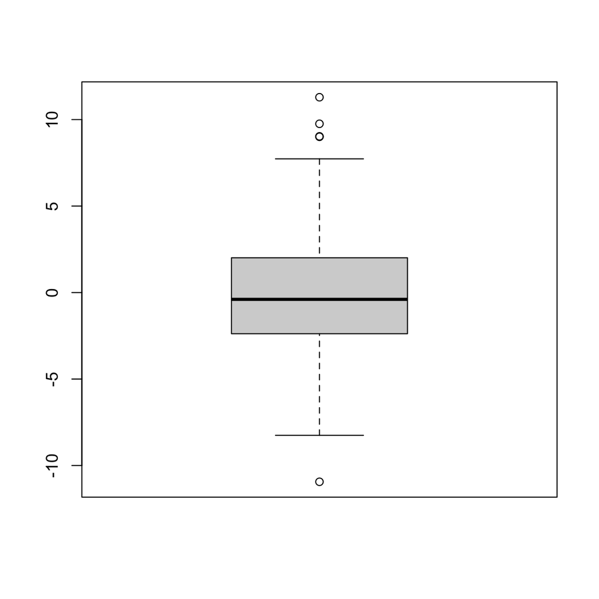

```r
boxplot(residuals(mass_SVL_SLR))
```

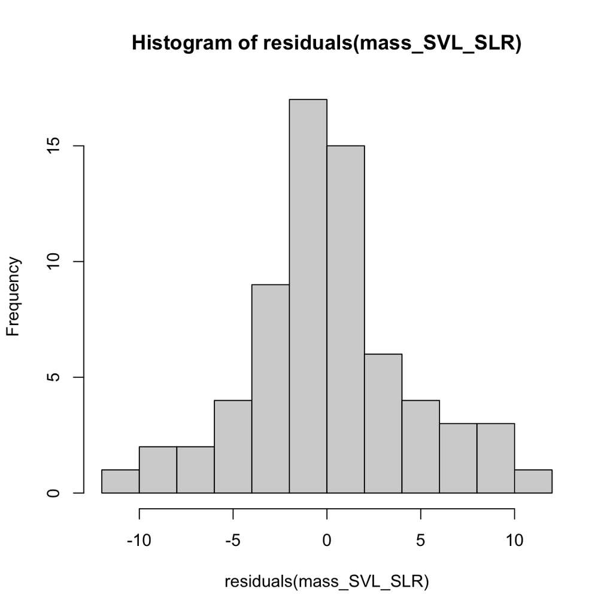

```r
hist(residuals(mass_SVL_SLR))
```

```r
max(residuals(mass_SVL_SLR))
```

```
## [1] 11.29217
```

```r
influential %>% dplyr::filter(residuals < -10)
```

```
##     capture_date_time capture_date radio_collar_serial  PIT_tag_ID
## 1 2021-04-24 11:27:00   2021-04-24                <NA> 844-868-054
##   individual_ID sex_M_F mass_g SVL_mm    tmt tmt_mass_change_g capture_to_msmt
## 1         W-012  Female     20     92 No Tmt                 0             108
##   hematocrit_percent cloacal_temp_C CEWL_g_m2h msmt_temp_C msmt_RH_percent
## 1                 26             35   6.946667    30.06667        14.63333
##    e_s_kPa msmt_VPD_kPa osmolality_mmol_kg_mean month week week_num
## 1 4.258322     3.635188                     372 April    1        1
##   ultrasound_date gravid_Y_N number_eggs largest_egg_diameter_cm
## 1            <NA>       <NA>          NA                      NA
##   largest_egg_circumference_cm stage dev_point residuals row          c
## 1                           NA  <NA>        NA -10.94067  51 0.06016034
```

```r
influential %>% dplyr::filter(residuals > 8)
```

```
##     capture_date_time capture_date radio_collar_serial  PIT_tag_ID
## 1 2021-04-23 16:07:00   2021-04-23             245-754 844-869-876
## 2 2021-04-23 11:39:00   2021-04-23             245-751 844-865-793
## 3 2021-04-23 15:27:00   2021-04-23             245-750 844-867-364
## 4 2021-04-24 11:50:00   2021-04-24                <NA> 835-840-572
##   individual_ID sex_M_F mass_g SVL_mm       tmt tmt_mass_change_g
## 1          M-07    Male     52    108 Water Tmt               0.0
## 2          F-03  Female     52    107 Water Tmt               1.8
## 3          M-15    Male     46    100  Sham Tmt              -1.0
## 4         W-015    Male     46     97    No Tmt               0.0
##   capture_to_msmt hematocrit_percent cloacal_temp_C CEWL_g_m2h msmt_temp_C
## 1            1578                 31             29   6.776667    25.73333
## 2             154                 33             34   8.403333    32.03333
## 3            1610                 37             30   9.736667    27.33333
## 4             124                 35             35  12.710000    30.96667
##   msmt_RH_percent  e_s_kPa msmt_VPD_kPa osmolality_mmol_kg_mean month week
## 1        24.80000 3.307037     2.486891                377.5000 April    1
## 2        14.20000 4.763440     4.087031                333.0000 April    1
## 3        22.43333 3.634071     2.818828                346.3333 April    1
## 4        15.43333 4.483366     3.791433                397.6667 April    1
##   week_num ultrasound_date gravid_Y_N number_eggs largest_egg_diameter_cm
## 1        1            <NA>       <NA>          NA                      NA
## 2        1      2021-04-24     Gravid           4                    0.99
## 3        1            <NA>       <NA>          NA                      NA
## 4        1            <NA>       <NA>          NA                      NA
##   largest_egg_circumference_cm       stage dev_point residuals row          c
## 1                           NA        <NA>        NA  9.004416   7 0.06699144
## 2                         2.88 large round         2  9.757849  13 0.07120973
## 3                           NA        <NA>        NA  9.031875  25 0.03462171
## 4                           NA        <NA>        NA 11.292172  54 0.05084612
```

From the boxplot, there are four individuals with much larger residuals than the rest of the distribution. The histogram looks fine, and pretty normally distributed.

Test whether removing the high-leverage pt and the high residuals improve things:

```r
cleaned_SMI_dat <- April_lizard_dat %>%
  dplyr::filter(individual_ID %nin% c("W-012", # super low residual
                                      "M-07", "F-03", "M-15", "W-015", # high resids
                                      "M-20" # influential pt
                                      ))
```

re-check residuals:

```r
mass_SVL_SLR2 <- lm(data = cleaned_SMI_dat, mass_g ~ SVL_mm)
summary(mass_SVL_SLR2)
```

```
##
## Call:
## lm(formula = mass_g ~ SVL_mm, data = cleaned_SMI_dat)
##
## Residuals:
##     Min      1Q  Median      3Q     Max
## -7.3535 -1.7156 -0.2373  1.8447  8.7673
##
## Coefficients:
##              Estimate Std. Error t value Pr(>|t|)
## (Intercept) -35.54644    4.17348  -8.517 7.34e-12 ***
## SVL_mm        0.71982    0.04294  16.765  < 2e-16 ***
## ---
## Signif. codes:  0 '***' 0.001 '**' 0.01 '*' 0.05 '.' 0.1 ' ' 1
##
## Residual standard error: 3.506 on 59 degrees of freedom
## Multiple R-squared:  0.8265, Adjusted R-squared:  0.8236
## F-statistic: 281.1 on 1 and 59 DF,  p-value: < 2.2e-16
```

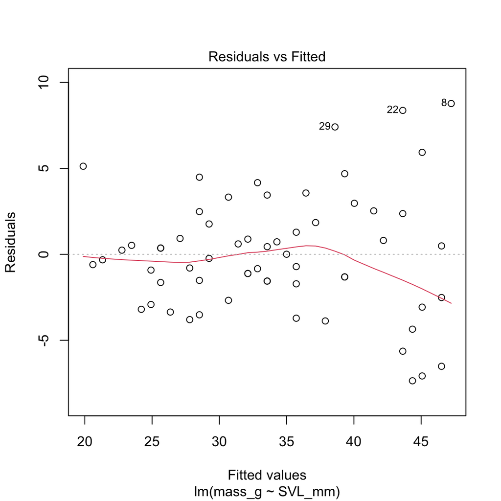

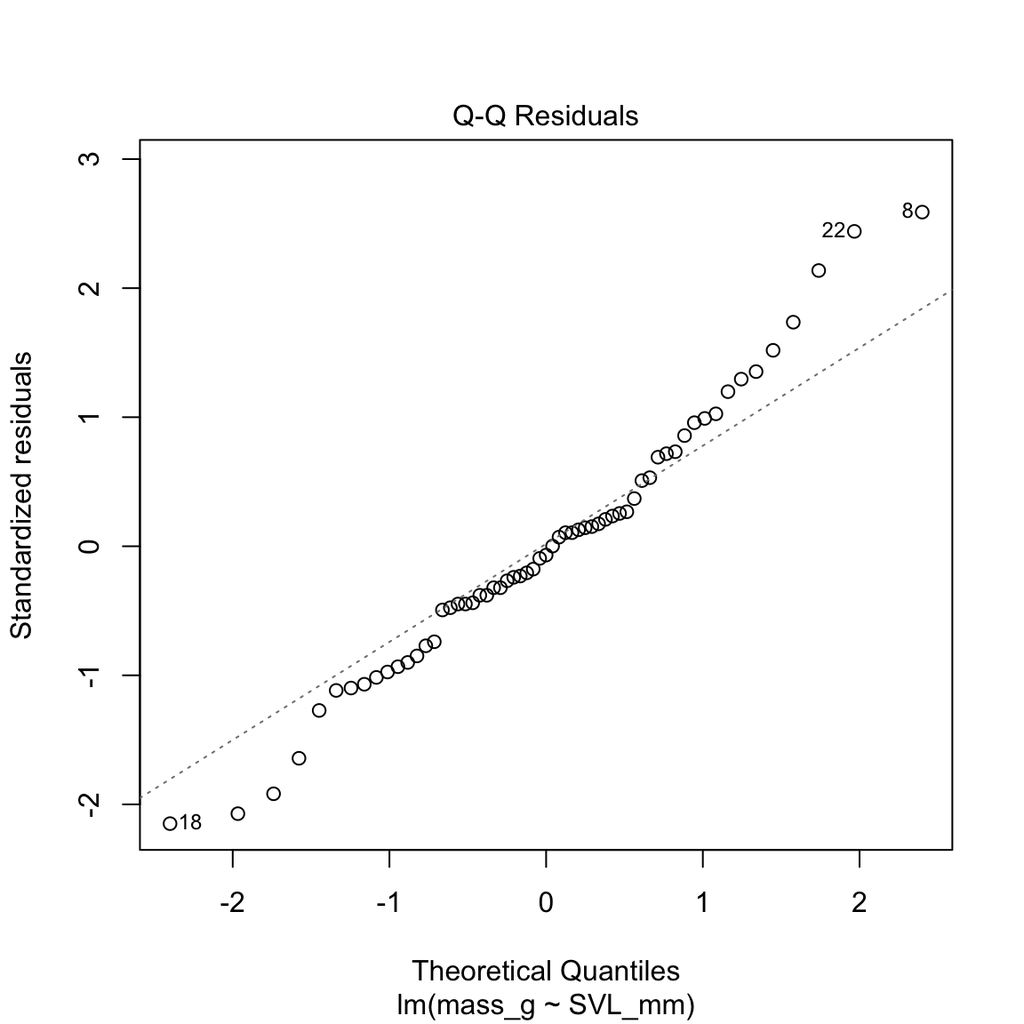

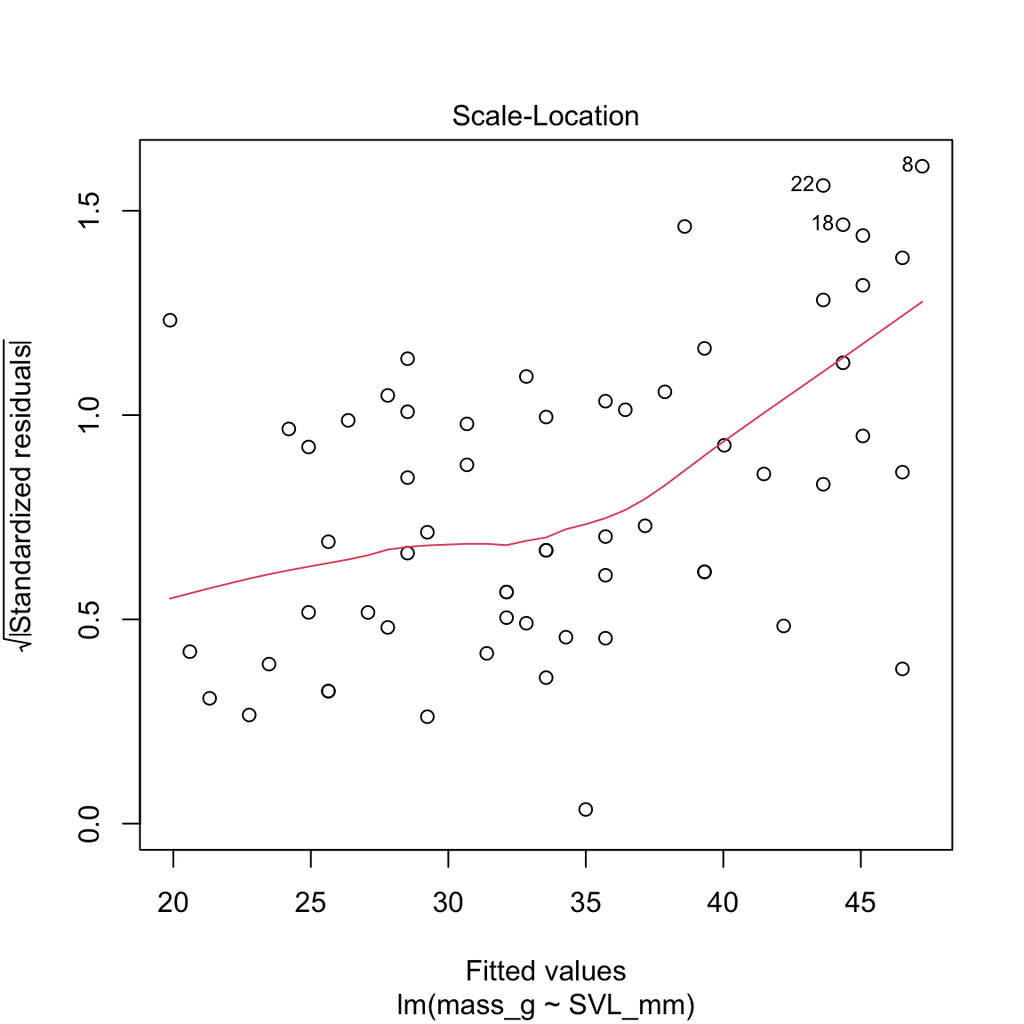

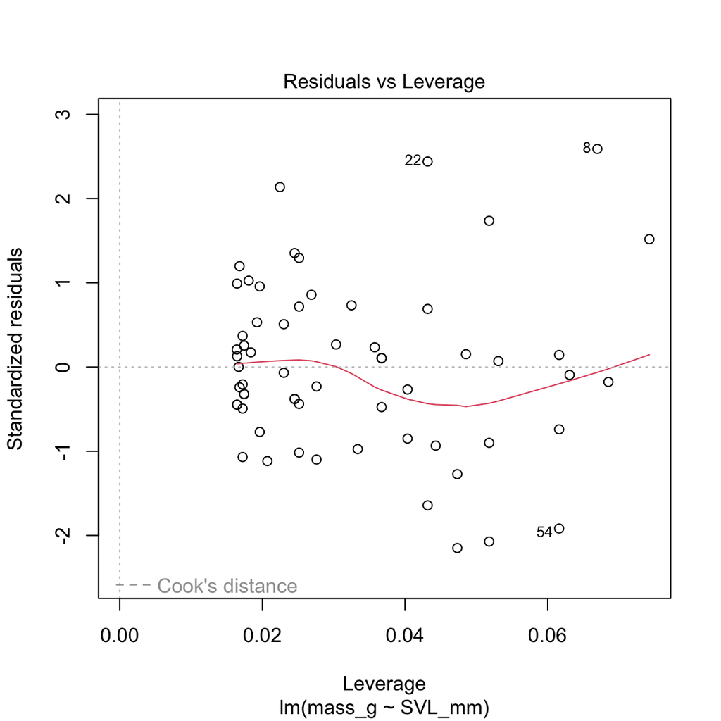

```r
plot(mass_SVL_SLR2)
```

```r
mean(residuals(mass_SVL_SLR2))
```

```
## [1] 2.68029e-17
```

```r
median(residuals(mass_SVL_SLR2))
```

```
## [1] -0.2372673
```

I don’t think removing those points improved things much with residuals, but R-sq is better, so I will keep the subsetted data.

Step 3: log-log Regression

```r
log_mass_SVL_SLR <- lm(data = cleaned_SMI_dat,
                       log(mass_g) ~ log(SVL_mm))
summary(log_mass_SVL_SLR)
```

```
##
## Call:
## lm(formula = log(mass_g) ~ log(SVL_mm), data = cleaned_SMI_dat)
##
## Residuals:
##       Min        1Q    Median        3Q       Max
## -0.187816 -0.065914 -0.004368  0.062061  0.186177
##
## Coefficients:
##             Estimate Std. Error t value Pr(>|t|)
## (Intercept)  -6.0401     0.5164  -11.70   <2e-16 ***
## log(SVL_mm)   2.0891     0.1131   18.47   <2e-16 ***
## ---
## Signif. codes:  0 '***' 0.001 '**' 0.01 '*' 0.05 '.' 0.1 ' ' 1
##
## Residual standard error: 0.09592 on 59 degrees of freedom
## Multiple R-squared:  0.8526, Adjusted R-squared:  0.8501
## F-statistic: 341.2 on 1 and 59 DF,  p-value: < 2.2e-16
```

Step 4: Extract Values

compute standardized major axis using the log-log regression equation:

```r
r <- sqrt(0.8526) # Pearson's correlection coefficient (sqrt of R-squared)
b_OLS <- 2.0891 # regression slope
b_SMA <- b_OLS/r
```

mean length in capture data:

```r
L0 <- mean(cleaned_SMI_dat$SVL_mm)
```

Step 5: Calculate Scaled Mass Index

```r
lizards_all_SMI <- merged_data %>%
  # compute SMI
  mutate(SMI = mass_g * ((L0/SVL_mm) ^ b_SMA))

summary(lizards_all_SMI)
```

```
##  capture_date_time                 capture_date        radio_collar_serial
##  Min.   :2021-04-23 10:39:00.00   Min.   :2021-04-23   Length:119
##  1st Qu.:2021-04-23 15:39:15.00   1st Qu.:2021-04-24   Class :character
##  Median :2021-04-24 12:22:00.00   Median :2021-04-24   Mode  :character
##  Mean   :2021-04-28 14:08:18.98   Mean   :2021-05-08
##  3rd Qu.:2021-05-07 13:16:45.00   3rd Qu.:2021-05-08
##  Max.   :2021-05-08 14:19:00.00   Max.   :2021-07-14
##  NA's   :21
##   PIT_tag_ID        individual_ID   sex_M_F       mass_g          SVL_mm
##  Length:119         F-12   :  3   Female:44   Min.   :20.00   Min.   : 77.0
##  Class :character   M-09   :  3   Male  :75   1st Qu.:31.00   1st Qu.: 93.5
##  Mode  :character   M-10   :  3               Median :37.00   Median : 99.0
##                     M-11   :  3               Mean   :36.94   Mean   : 99.0
##                     M-19   :  3               3rd Qu.:43.00   3rd Qu.:106.5
##                     M-20   :  3               Max.   :58.80   Max.   :122.0
##                     (Other):101
##         tmt     tmt_mass_change_g capture_to_msmt   hematocrit_percent
##  Water Tmt:38   Min.   :-3.0000   Min.   :  10.00   Min.   :10.00
##  Sham Tmt :38   1st Qu.:-0.1500   1st Qu.:  49.25   1st Qu.:30.00
##  No Tmt   :43   Median : 0.0000   Median : 117.50   Median :34.00
##                 Mean   :-0.1327   Mean   : 276.18   Mean   :33.78
##                 3rd Qu.: 0.0000   3rd Qu.: 228.75   3rd Qu.:38.00
##                 Max.   : 3.0000   Max.   :1665.00   Max.   :58.00
##                 NA's   :15        NA's   :21        NA's   :3
##  cloacal_temp_C    CEWL_g_m2h      msmt_temp_C    msmt_RH_percent
##  Min.   :22.00   Min.   : 0.650   Min.   :19.00   Min.   :11.84
##  1st Qu.:31.00   1st Qu.: 8.486   1st Qu.:28.57   1st Qu.:14.64
##  Median :33.00   Median :10.381   Median :30.38   Median :16.12
##  Mean   :32.22   Mean   :10.272   Mean   :29.43   Mean   :20.90
##  3rd Qu.:34.00   3rd Qu.:12.881   3rd Qu.:31.52   3rd Qu.:23.78
##  Max.   :36.00   Max.   :21.673   Max.   :33.55   Max.   :40.22
##                  NA's   :1        NA's   :1       NA's   :1
##     e_s_kPa       msmt_VPD_kPa   osmolality_mmol_kg_mean   month    week
##  Min.   :2.196   Min.   :1.371   Min.   :309.3           April:67   1 :67
##  1st Qu.:3.906   1st Qu.:2.946   1st Qu.:348.2           May  :37   3 :37
##  Median :4.336   Median :3.635   Median :366.5           July :15   12:15
##  Mean   :4.160   Mean   :3.332   Mean   :367.8
##  3rd Qu.:4.626   3rd Qu.:3.960   3rd Qu.:379.9
##  Max.   :5.188   Max.   :4.319   Max.   :437.3
##  NA's   :1       NA's   :1       NA's   :3
```

[output cut: 9 more lines]

```
##  Min.   :0.5700          Min.   :1.710                small round:  1
##  1st Qu.:0.8425          1st Qu.:2.385                large round:  9
##  Median :0.9950          Median :2.885                soft       :  2
##  Mean   :1.1131          Mean   :3.148                soft oblong:  1
##  3rd Qu.:1.4200          3rd Qu.:3.985                firm oblong:  2
##  Max.   :1.8000          Max.   :4.740                hard oblong:  1
##  NA's   :103             NA's   :103                  NA's       :103
##    dev_point         SMI
##  Min.   :1.00   Min.   :22.35
##  1st Qu.:2.00   1st Qu.:31.58
##  Median :2.00   Median :34.29
##  Mean   :2.75   Mean   :34.57
##  3rd Qu.:3.25   3rd Qu.:37.33
##  Max.   :5.00   Max.   :45.63
##  NA's   :103
```

# Export Finished Dataframe

```r
write_rds(lizards_all_SMI, "./data/G_sila_clean_full_dat.RDS")
```